# mixed models: introduction

18 November 2025

## Table of contents

## Overview

## Acknowledgements

- shoulders of giants
- especially
  - Doug Bates, Martin Mächler, Steve Walker (`lme4`)
  - Kasper Kristensen, Mollie Brooks (`glmmTMB`)
- the R community, `r-sig-mixed-models` denizens, bug reporters …
- McMaster, NSERC, Univ Florida, US NSF, BIRS

## Mixed models

- *tabular* data (row = observation, column = variable)
- *regression* models
  - continuous and categorical *predictor* variables
  - single (univariate) numeric *response* variable
- with one or more *grouping variables* (‘blocks’, ‘clusters’, …)
- for prediction or inference
- typically for ‘medium-sized’ data (e.g. \(10^6\) rows, \(10^3\) clusters, 10-20 predictors)

## Mixed models (easy version)

- take a standard linear-type model (e.g. \(y_i = a + b x_i + \epsilon_i\))
- … but observations fall in *groups*
- breaks assumption of independence (*pseudoreplication*)
- add *between-group* (random) variation: \[ y_{ij} = a + b x_{ij} + \alpha_i + \epsilon_{ij} \]

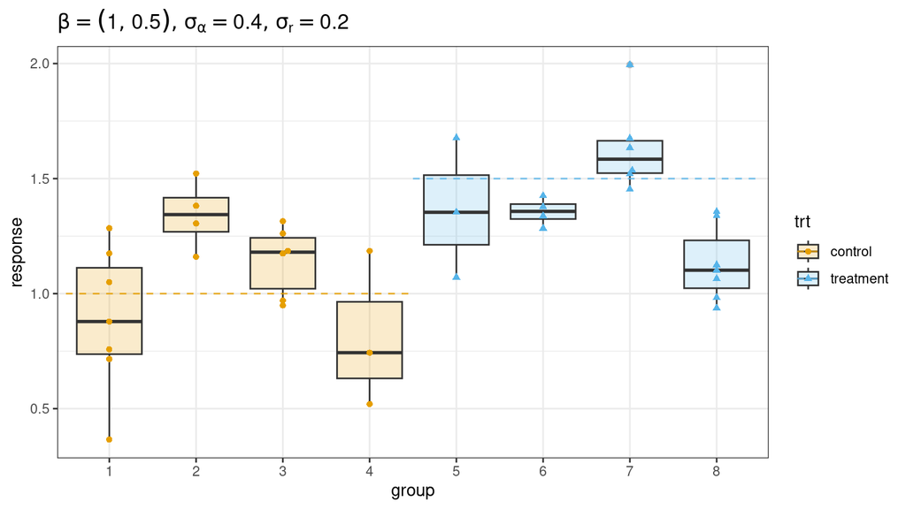

## The mixed model universe

- more complex *fixed effects* components (multivariate regression, multiway ANOVA, ANCOVA, …)
- multiple grouping variables (random effects *terms*); multiple effects per group (“*random slopes*”)
- interesting *conditional distributions*
  - exponential dispersion family (à la GLMs): binomial/Poisson/etc.
  - weirder: Tweedie, \(t\) distribution, Beta, …
- nonlinearity: *link functions* (log, logit, etc.)
- structured covariances: autoregressive, compound symmetry, regression splines …

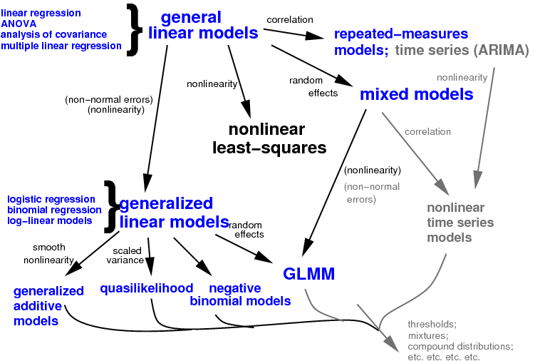

## Examples

## Experimental: bloodworm cell survival

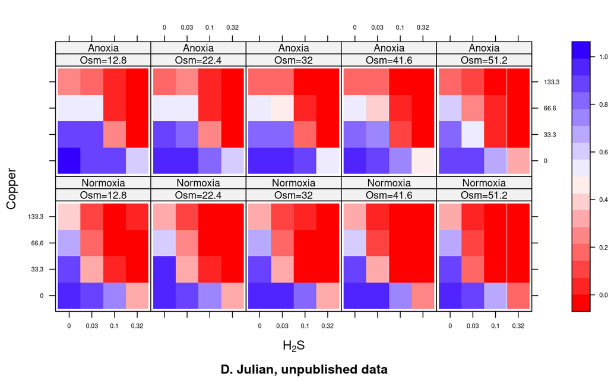

## *Arabidopsis*: fertilization & herbivory

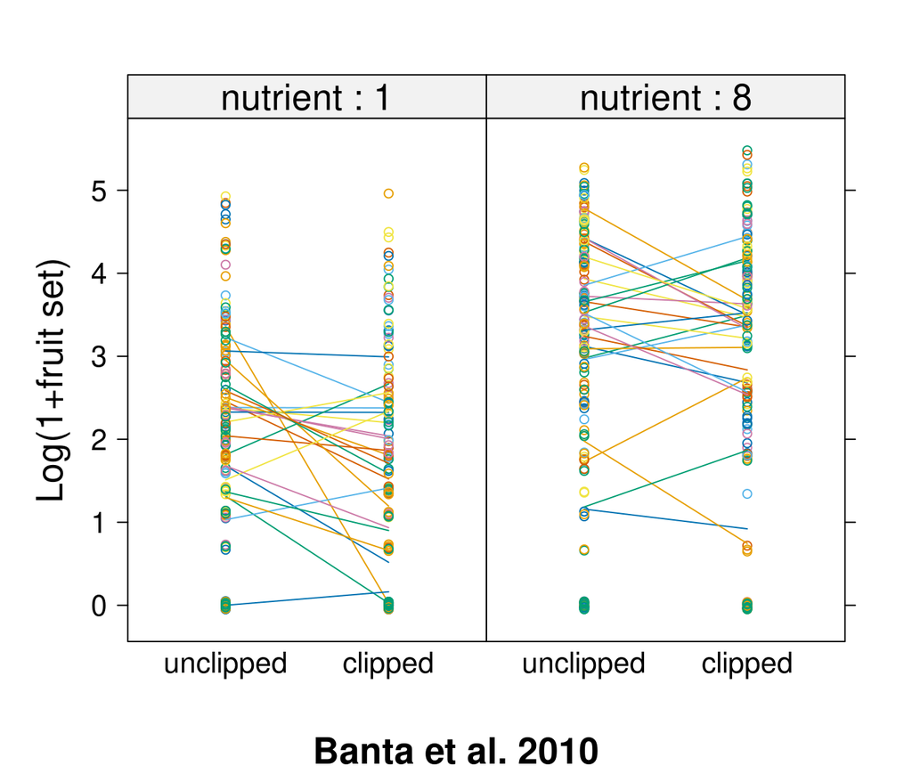

## Wildfire/diversity (Moritz et al. 2023)

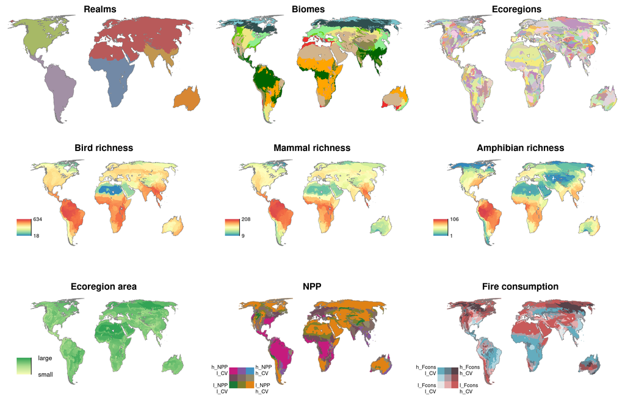

## Sleep deprivation study

Belenky et al. (2003)

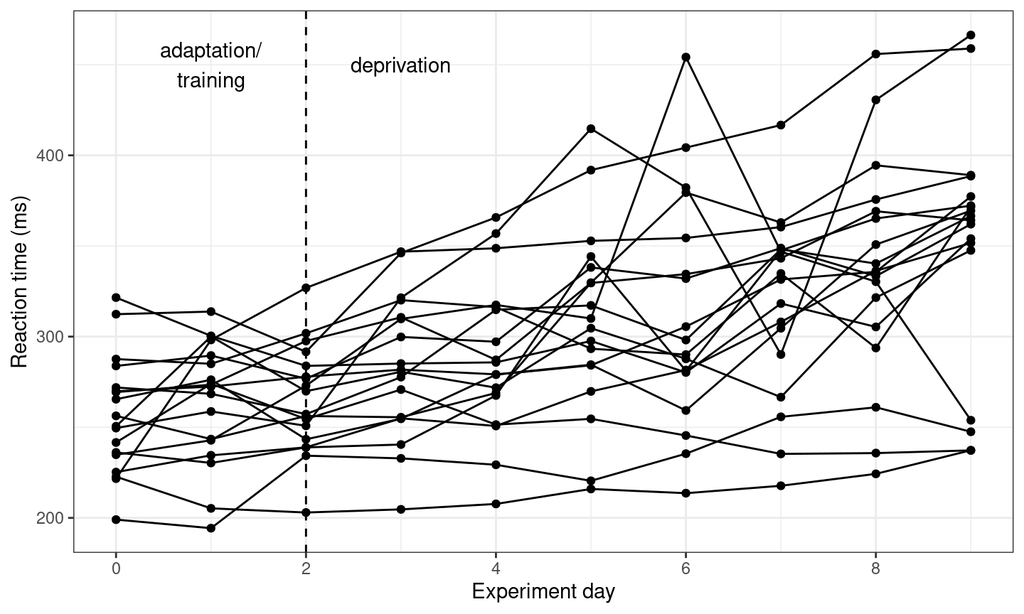

## Definitions and descriptions

## Simple mixed models (scalar, intercept-only)

\[ \begin{split} y_{ij} & = \beta_0 + \beta_1 x_{ij} + \epsilon_{0,ij} + \epsilon_{1,j} \\ & = (\beta_0 + \epsilon_{1,j}) + \beta_1 x_{ij} + \epsilon_{0,ij} \\ \epsilon_{0,ij} & \sim \textrm{Normal}(0,\sigma_0^2) \\ \epsilon_{1,j} & \sim \textrm{Normal}(0,\sigma_1^2) \end{split} \]

- Could have multiple, nested levels of random effects  
  (genotype within population within region …), or *crossed* REs

## Random-slopes model

\[ \begin{split} y_{ij} & = \beta_0 + \beta_1 x_{ij} + \epsilon_{0,ij} + \epsilon_{1,j} + \epsilon_{2,j} x_{ij} \\ & = (\beta_0 + \epsilon_{1,j}) + (\beta_1 + \epsilon_{2,j}) x_{ij} + \epsilon_{0,ij} \\ \epsilon_{0,ij} & \sim \textrm{Normal}(0,\sigma_0^2) \\ \{\epsilon_{1,j}, \epsilon_{2,j}\} & \sim \textrm{MVN}(0,\Sigma) \end{split} \]

- variation in the *effect* of a treatment or covariate across groups
- correlated variation in intercepts/slopes

## Terminology

- **grouping variables** define sets of clusters (e.g. school, year, country …)
- **varying effects**: predictors whose effects vary across clusters (e.g. intercept, herbivory, time)
- random effects **term**: the combination of a clustering variable and a set of varying effects
- **conditional mode** (“BLUP”): the predicted value of the *difference* of a cluster effect from the population mean
- **conditional distribution**: distribution of the data (Gaussian, Poisson, binomial, Beta, Tweedie, …)

## General definition

\[ \begin{split} \underbrace{Y_i}_{\text{response}} & \sim \overbrace{\text{Distr}}^{\substack{\text{conditional} \\ \text{distribution}}}(\underbrace{g^{-1}(\eta_i)}_{\substack{\text{inverse} \\ \text{link} \\ \text{function}}},\underbrace{\phi}_{\substack{\text{scale} \\ \text{parameter}}}) \\ \underbrace{\boldsymbol \eta}_{\substack{\text{linear} \\ \text{predictor}}} & = \underbrace{\boldsymbol X \boldsymbol \beta}_{\substack{\text{fixed} \\ \text{effects}}} + \underbrace{\boldsymbol Z \boldsymbol b}_{\substack{\text{random} \\ \text{effects}}} \\ \underbrace{\boldsymbol b}_{\substack{\text{conditional} \\ \text{modes}}} & \sim \text{MVN}(\boldsymbol 0, \underbrace{\Sigma(\boldsymbol \theta)}_{\substack{\text{variance-} \\ \text{covariance} \\ \text{matrix}}}) \end{split} \]

## What are random effects?

A method for …

- accounting for among-individual variation, within-cluster correlation
- compromising between  
  *complete pooling* (no among-cluster variance)  
  and *fixed effects* (large among-cluster variance)
- handling levels selected at random from a larger population
- sharing information among clusters (*shrinkage estimation*)
- estimating among-cluster variability
- allowing predictions for unobserved clusters
- modeling **exchangeable** groups

## Random-effect myths

- clusters must always be sampled at random
- a complete sample cannot be treated as a random effect
- random effects are always a *nuisance variable*
- nothing can be said about the predictions of a random effect
- you should always use a random effect no matter how few clusters you have

## Reasons for random effects (inferential/philosophical)

- **don’t** want to
  - test hypotheses about differences between responses at particular levels of the grouping variable;
- **do** want to
  - quantify variation among groups
  - make predictions about unobserved groups
- have levels that are randomly sampled from/representative of a larger population (*exchangeable*)

## Reasons for random effects (practical)

- want to combine information across groups
- have variation in information per level (number of samples or noise level)
- have a categorical predictor that is a nuisance variable (i.e., not of direct interest, but needs to be controlled for)
- have more than 5-10 levels (Clarke 2008; Austin et al. 2018)

See also Crawley (2002); Gelman (2005)

## Avoiding mixed models

- average: for *nested* (balanced) LMMs (Murtaugh 2007)
- use fixed effects (or *two-stage models*) instead of random effects when there are
  - many observations per cluster (shrinkage unimportant)
  - few clusters (little advantage in # parameters; bad variance estimates)

## Model setup

## Formulas

- random effects specified with `|` (“pipe”/“bar”)  
  as `(1+a|g1) + (1+b|g2) + ...`
- right-hand side (`g1`, `g2`) is the *grouping variable* (always treated as categorical, usually a factor)
- left-hand side describes the *varying terms* (`1` [intercept], `a`, `b`)
- `+` separates independent terms
- formulas: empower but conceal details (McElreath 2015)

## Formula definitions

[output not shown]

Modified from: http://stats.stackexchange.com/questions/13166/rs-lmer-cheat-sheet?lq=1 (Livius). Subscripts \(\{S,I\}\) refer to Subject vs Item effects. Lower-case \(\{s,i\}\) indicate particular subjects/items. \(\{0,1\}\) refer to intercept vs slope effects.

## Nesting vs crossing

Nested: sub-unit IDs only measured within a single larger unit. e.g.: Class1 in School1 independent of Class1 in School2

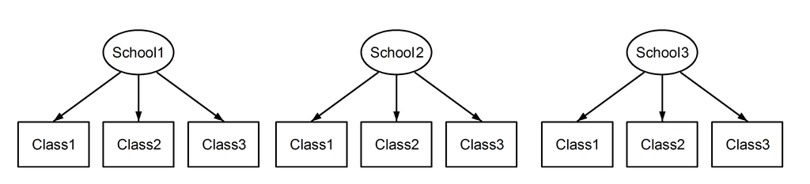

Crossed: sub-unit IDs can be measured in multiple larger units. e.g.

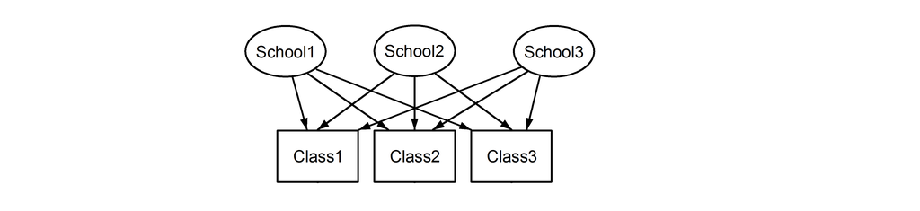

Unique coding: removes ambiguity

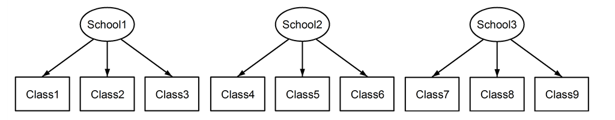

Robert Long, [Cross Validated](https://stats.stackexchange.com/questions/228800/crossed-vs-nested-random-effects-how-do-they-differ-and-how-are-they-specified)

## Formulas, interactions, nesting etc.

- Nested: `(1|f/g)` \(\equiv\) `(1|f) + (1|f:g)`. Subplots vary within plots, no commonality across plots
- Crossed: `(1|f) + (1|g)`. Years vary; plots vary independently
- Crossed+: `(1|f*g)` \(\equiv\) `(1|f) + (1|g) + (1|f:g)`. Years vary, plots vary independently, plots vary within years (need >1 observation per plot/year combination, for LMMs).

**Don’t need explicit nesting** if sub-groups are uniquely labeled (i.e. `A1`, `A2`, …, `B1`, `B2`, …)

## example covariance matrices

- 10 groups, 5 obs/group, intercept RE

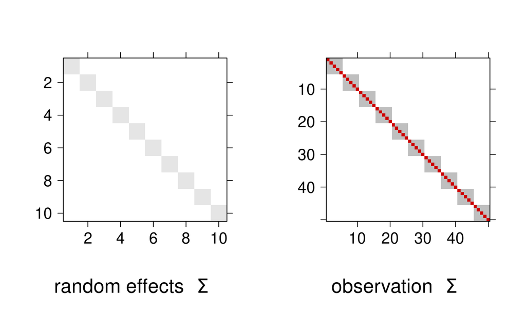

## example covariance matrices

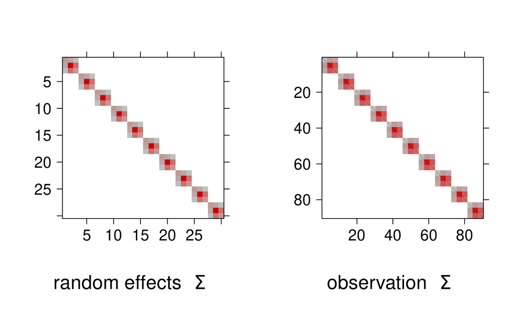

## example covariance matrices

- 5 groups, 2 effects (v1) × 5 groups, 1 effect (v2)

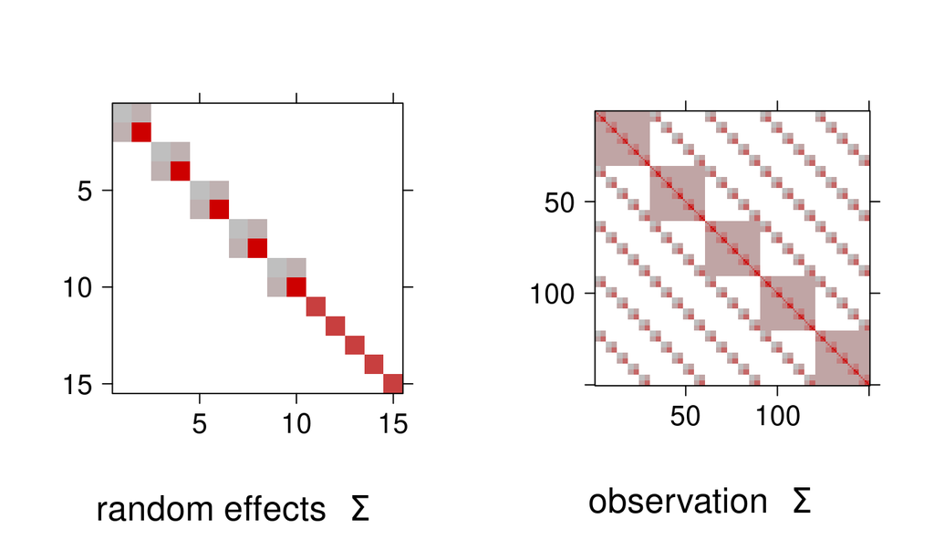

## example covariance matrices

Moritz et al. (2023) (fire/diversity; blocks are geographic regions)

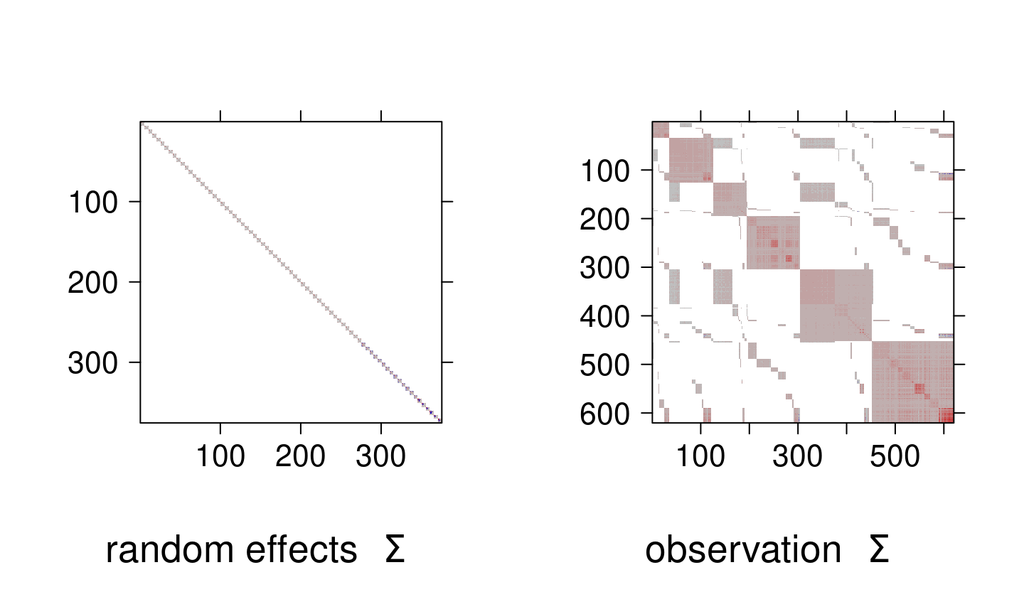

## Factors varying across groups

Can generate large variance-covariance matrices. For a four-level factor, we have \(\beta_0\) (intercept), \(\beta_1\) (level 2 - level 1), \(\beta_2\) (level 3 - level 1), \(\beta_3\) (level 4 - level 1).

\[ \Sigma = \left[ \begin{array}{cccc} \sigma^2_{\{b|1\}} & . & . & . \\ \sigma_{\{b|1\},\{b|a_{21}\}} & \sigma^2_{\{b|a_{21}\}} & . & . \\ \sigma_{\{b|1\}, \{b|a_{31}\}} & \sigma_{\{b|a_{21}\},\{b|a_{31}\}} & \sigma^2_{\{b|a_{31}\}} & . \\ \sigma_{\{b|1\} ,\{b|a_{41}\}} & \sigma_{\{b|a_{21}\},\{b|a_{41}\}} & \sigma_{\{b|a_{31}\},\{b|a_{41}\}} & \sigma^2_{\{b|a_{41}\}} \end{array} \right] \]

## What is the maximal model?

- Which effects vary *within* which groups?
- If effects don’t vary within groups, then we *can’t* estimate among-group variation in the effect
  - e.g. in typical clinical trials each patient gets only one treatment (placebo or drug)
  - convenient
  - maybe less powerful (among-group variation is lumped into residual variation)
  - can’t evaluate variation in effects

## Estimation

## Maximum likelihood estimation

- Best fit is a compromise between
  - consistency of data with fixed effects + conditional modes
  - consistency of random effect with RE distribution
- Goodness-of-fit *integrates* over the RE distribution

\[ \mathcal L(x|\beta,\theta) = \iint \mathcal L(x|\beta,\boldsymbol b) \cdot \mathcal L(\boldsymbol b|\Sigma(\theta)) \, d \boldsymbol b \]

## Restricted maximum likelihood (REML)

- factor out fixed effects when estimating variances
- analogous to estimating \(s^2 = \frac{\textrm{SSQ}}{n-1}\) rather than \(\frac{\textrm{SSQ}}{n}\)
- typically better variance estimates (unbiased in simple cases)
- defaults differ across packages
- **never** compare models with differing fixed effects fitted by REML

## Shrinkage

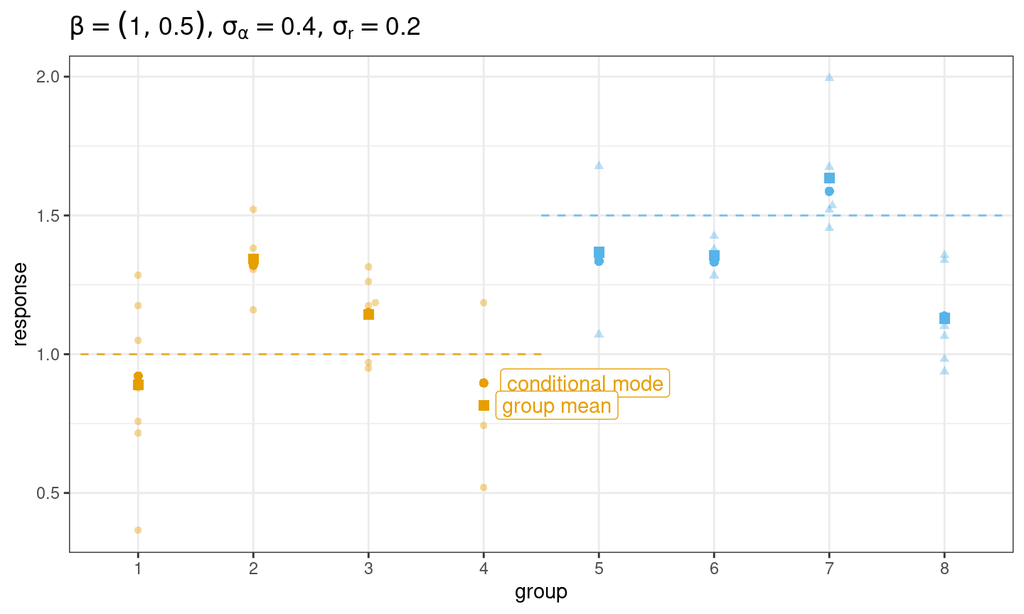

## *Arabidopsis* shrinkage

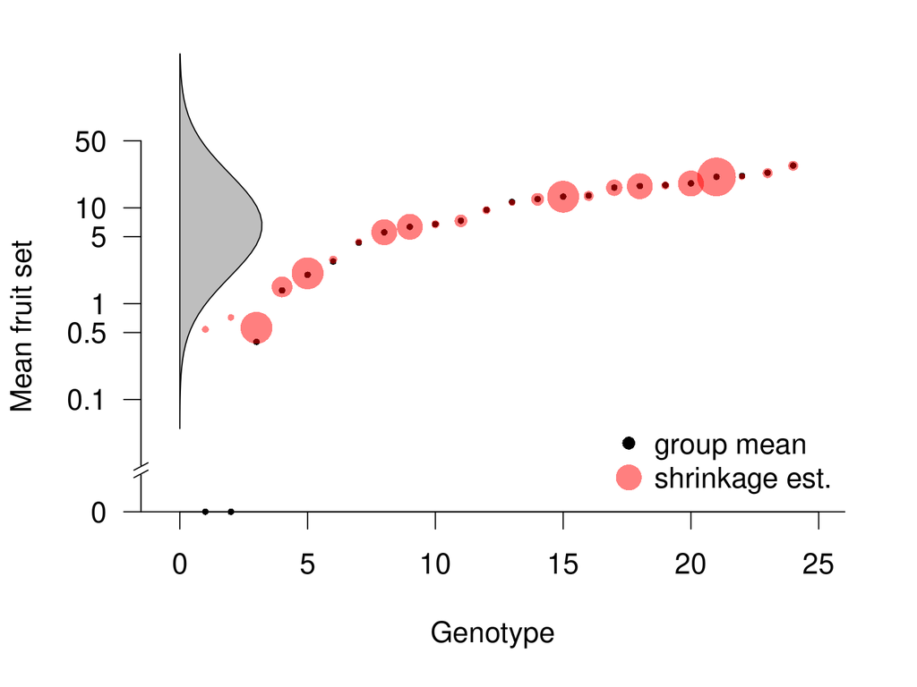

## Shrinkage in the sleep-study model

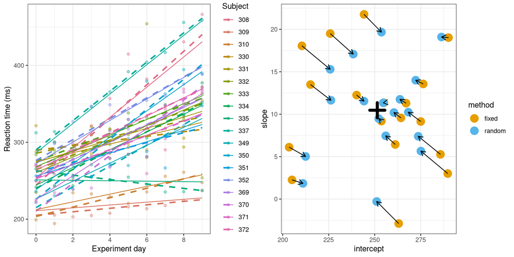

## Methods

## Estimation methods

Integrating the likelihood is hard (for GLMMs)

- **deterministic**
  - penalized quasi-likelihood (Breslow 2004), Laplace, Gauss-Hermite quadrature, … (Biswas 2015; Bilodeau et al. 2024)
  - need best methods for small clusters (binary, small # of observations)
  - available methods depend on problem structure
  - accuracy (GHQ) vs. flexibility and speed (PQL, Laplace)
- **stochastic** (Monte Carlo): mostly Bayesian, some frequentist
  - Booth et al. (1999); Gelman et al. (2006); Sung et al. (2007); Ponciano et al. (2009); McElreath (2015)
  - much slower, but flexible and accurate

## Estimation: *Arabidopsis*

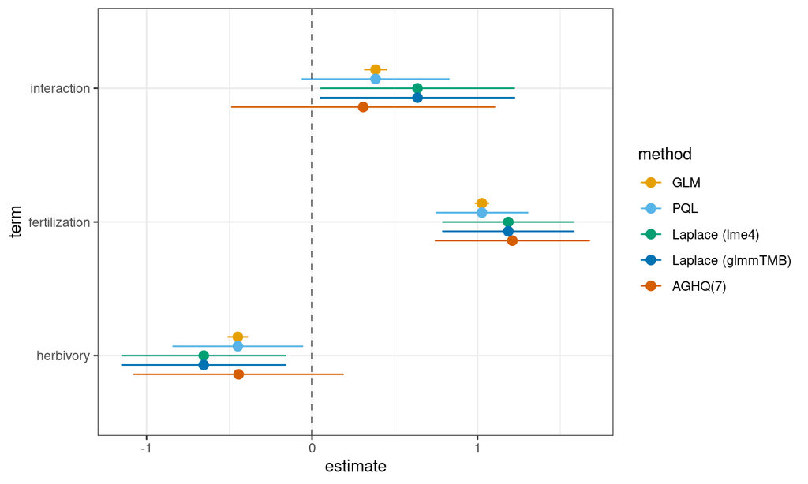

## Inference/post-fitting

## Diagnostics

- make sure model is working OK (**singular fits** etc.)
- check model assumptions
  - generalizations of linear/GLM diagnostics: residuals vs fitted, scale-location, etc.
  - conditional modes should be Normally distributed
  - simulation-based residuals (`DHARMa`)

## Parameter/model interpretation

- fixed effects: same as linear models (population level trends/effects)
- conditional modes/group-level effects
  - deviations from population-level effects
  - can get *conditional standard deviations*, but can’t test significance!
- interpreting random effects
  - standard deviations (on same scale as corresponding fixed effects)
  - variances (for population geneticists)

## references

Austin, PC et al. 2018. *Journal of Statistical Computation and Simulation* 88 (16) (November): 3151–3163. doi:10.1080/00949655.2018.1504945.

Banta, JA et al. 2010. *Oikos* 119 (2) (February): 359–369. doi:10.1111/j.1600-0706.2009.17726.x.

Belenky, G et al. 2003. *Journal of Sleep Research* 12 (1): 1–12. doi:10.1046/j.1365-2869.2003.00337.x.

Bilodeau, B et al. 2024. *Journal of the American Statistical Association* 119 (545) (January): 690–700. doi:10.1080/01621459.2022.2141635.

Biswas, K. 2015. Master’s thesis, McMaster University. https://macsphere.mcmaster.ca/bitstream/11375/17272/2/M.Sc_Thesis_final_Keya_Biswas.pdf.

Booth, JG et al. 1999. *Journal of the Royal Statistical Society. Series B* 61 (1): 265–285. doi:10.1111/1467-9868.00176.

Breslow, NE. 2004. In *Proceedings of the second Seattle symposium in biostatistics: Analysis of correlated data*, ed by. Danyu Y. Lin et al., 1–22. Springer.

Clarke, P. 2008. *Journal of Epidemiology & Community Health* 62 (8) (August): 752–758. doi:10.1136/jech.2007.060798.

Crawley, MJ. 2002. *Statistical computing: An introduction to data analysis using S-PLUS*. John Wiley & Sons.

Gelman, A. 2005. *Annals of Statistics* 33 (1): 1–53. doi:doi:10.1214/009053604000001048.

Gelman, A et al. 2006. *Data analysis using regression and Multilevel/Hierarchical models*. Cambridge, England: Cambridge University Press. http://www.stat.columbia.edu/~gelman/arm/.

Heisig, JP et al. 2019. *European Sociological Review* 35 (2) (April): 258–279. doi:10.1093/esr/jcy053.

McElreath, R. 2015. *Statistical Rethinking: A Bayesian Course with Examples in R and Stan*. Boca Raton: Chapman; Hall/CRC.

Moritz, MA et al. 2023. *Ecology Letters* 26 (4): 563–574. doi:10.1111/ele.14177.

Murtaugh, PA. 2007. *Ecology* 88 (1): 56–62. doi:10.1890/0012-9658(2007)88[56:SACIED]2.0.CO;2.

Oberauer, K. 2022. *Psychological Science* 33 (4) (April): 648–665. doi:10.1177/09567976211046884.

Ponciano, JM et al. 2009. *Ecology* 90 (2) (February): 356–362. http://www.jstor.org/stable/27650990.

Schielzeth, H et al. 2009. *Behavioral Ecology* 20 (2) (March): 416–420. doi:10.1093/beheco/arn145. http://beheco.oxfordjournals.org/content/20/2/416.

Sung, YJ et al. 2007. *The Annals of Statistics* 35 (3) (July): 990–1011. doi:10.1214/009053606000001389.